# Ex19 Formatges

PIE2

Tardor 2019-2020

###En l’elaboració de formatges, el rendiment és la relació entre el pes del formatge obtingut i el de la llet utilitzada. Es vol veure, per separat en llet de cabra, d’ovella i de vaca; com canvia el rendiment amb un tractament tèrmic (crua/pasteuritzada) i amb l’addició de CaCl2 (si/no).

Les dades són al fitxer “formatges.csv”.

Per cadascun dels tres tipus de llet per separat, suposant que es compleixen les hipòtesis dels models lineals i amb $\alpha=0.05$:

**Directori de treball, dades i paquets del R**

```r
#setwd("...")
dd <- read.csv2("../data/formatges.csv")

library(tables)
library(emmeans)
library(car)
library(RcmdrMisc)
```

==========================================================================================================

### **Let de VACA**

**Descriptiva**

```r
print(tabular(mean*VACA*(TERMIC+1)~(CaCl2+1),dd),justification="r")
```

```
##
##                          CaCl2
##                   TERMIC   amb sense   All
##  mean VACA          crua 39.81 58.56 49.19
##            pasteuritzada 46.00 50.54 48.27
##                      All 42.90 54.55 48.73
```

```r
print(tabular(sd*VACA*(TERMIC)~(CaCl2),dd),justification="r")
```

```
##
##                        CaCl2
##                 TERMIC   amb sense
##  sd VACA          crua 4.889 3.556
##          pasteuritzada 4.279 4.388
```

```r
print(tabular((n=1)*VACA*(TERMIC+1)~(CaCl2+1),dd),justification="r")
```

```
##
##                       CaCl2
##                TERMIC   amb sense All
##  n VACA          crua     4     4   8
##         pasteuritzada     4     4   8
##                   All     8     8  16
```

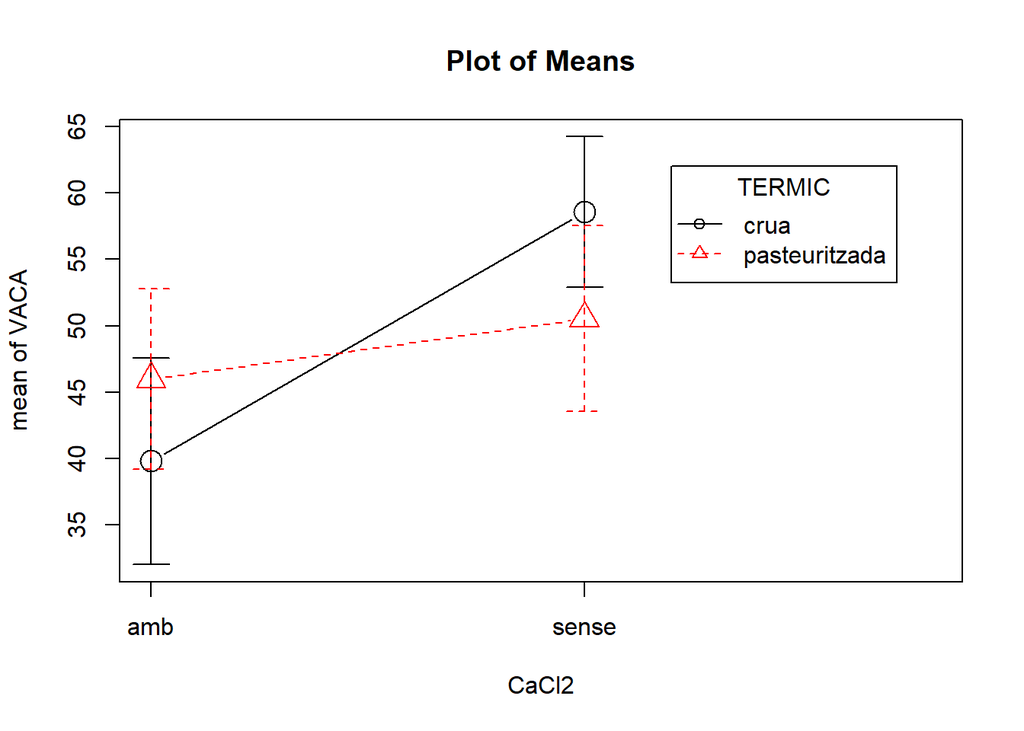

```r
#with(dd, plotMeans(VACA, TERMIC, CaCl2, error.bars="conf.int", level=0.95, connect=TRUE))
with(dd, plotMeans(VACA, CaCl2, TERMIC, error.bars="conf.int", level=0.95, connect=TRUE))
```

1. Plantegeu el model factorial:

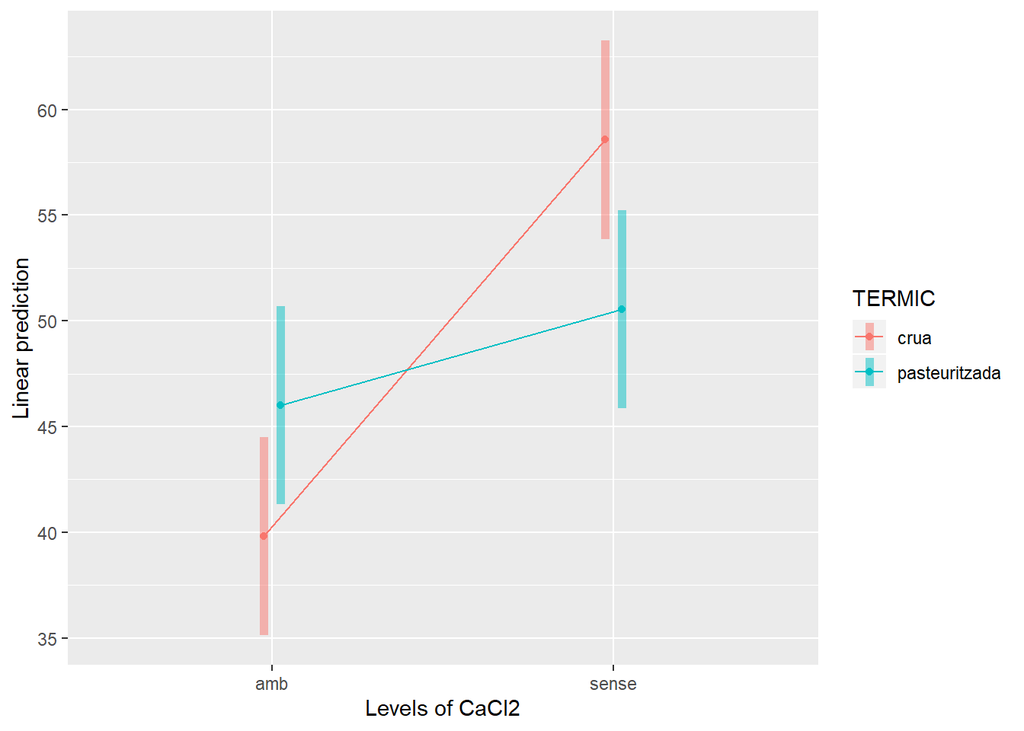

```r
mv<-lm(VACA~TERMIC*CaCl2,dd)
mv0<-lm(VACA~1,dd)
emmip(mv,TERMIC~CaCl2,CIs=T)
```

```r
#emmip(mv,CaCl2~TERMIC,CIs=T)
```

Tenen algun efecte els tractaments (combinacions dels nivells dels dos factors) utilitzats? En cas afirmatiu responeu justificadament les preguntes següents:

```r
# Omnibus
anova(mv0,mv)
```

```
## Analysis of Variance Table
##
## Model 1: VACA ~ 1
## Model 2: VACA ~ TERMIC * CaCl2
##   Res.Df    RSS Df Sum of Sq      F    Pr(>F)
## 1     15 970.56
## 2     12 222.34  3    748.22 13.461 0.0003799 ***
## ---
## Signif. codes:  0 '***' 0.001 '**' 0.01 '*' 0.05 '.' 0.1 ' ' 1
```

```r
#Anova tipus II
Anova(mv)
```

```
## Anova Table (Type II tests)
##
## Response: VACA
##              Sum Sq Df F value    Pr(>F)
## TERMIC         3.35  1   0.181 0.6780528
## CaCl2        542.83  1  29.297 0.0001568 ***
## TERMIC:CaCl2 202.03  1  10.904 0.0063162 **
## Residuals    222.34 12
## ---
## Signif. codes:  0 '***' 0.001 '**' 0.01 '*' 0.05 '.' 0.1 ' ' 1
```

• Quin és el millor o els millors tractaments?

```r
(emm<-emmeans(mv,~TERMIC*CaCl2))
```

```
##  TERMIC        CaCl2 emmean   SE df lower.CL upper.CL
##  crua          amb     39.8 2.15 12     35.1     44.5
##  pasteuritzada amb     46.0 2.15 12     41.3     50.7
##  crua          sense   58.6 2.15 12     53.9     63.3
##  pasteuritzada sense   50.5 2.15 12     45.9     55.2
##
## Confidence level used: 0.95
```

```r
# Comparacions dels tractaments
pairs(emm)
```

```
##  contrast                                estimate   SE df t.ratio p.value
##  crua,amb - pasteuritzada,amb               -6.19 3.04 12 -2.034  0.2294
##  crua,amb - crua,sense                     -18.76 3.04 12 -6.162  0.0002
##  crua,amb - pasteuritzada,sense            -10.73 3.04 12 -3.527  0.0189
##  pasteuritzada,amb - crua,sense            -12.56 3.04 12 -4.128  0.0066
##  pasteuritzada,amb - pasteuritzada,sense    -4.54 3.04 12 -1.492  0.4713
##  crua,sense - pasteuritzada,sense            8.02 3.04 12  2.636  0.0882
##
## P value adjustment: tukey method for comparing a family of 4 estimates
```

```r
#CLD(emm)
CLD(emm,Letters=letters,reversed=T)
```

```
##  TERMIC        CaCl2 emmean   SE df lower.CL upper.CL .group
##  crua          sense   58.6 2.15 12     53.9     63.3  a
##  pasteuritzada sense   50.5 2.15 12     45.9     55.2  ab
##  pasteuritzada amb     46.0 2.15 12     41.3     50.7   bc
##  crua          amb     39.8 2.15 12     35.1     44.5    c
##
## Confidence level used: 0.95
## P value adjustment: tukey method for comparing a family of 4 estimates
## significance level used: alpha = 0.05
```

• El CaCl2 té algun efecte sobre el rendiment? *Sí, tant en l’efecte principal com en la interacció*

• Podem dir que afegir CaCl2 fa augmentar el rendiment? *No, en llet crua el disminueix. En llet pasteuritzada no es detecten diferències*

```r
pairs(emmeans(mv,~CaCl2|TERMIC))
```

```
## TERMIC = crua:
##  contrast    estimate   SE df t.ratio p.value
##  amb - sense   -18.76 3.04 12 -6.162  <.0001
##
## TERMIC = pasteuritzada:
##  contrast    estimate   SE df t.ratio p.value
##  amb - sense    -4.54 3.04 12 -1.492  0.1614
```

```r
CLD(emmeans(mv,~CaCl2|TERMIC),Letters=letters,reversed=T)
```

```
## TERMIC = crua:
##  CaCl2 emmean   SE df lower.CL upper.CL .group
##  sense   58.6 2.15 12     53.9     63.3  a
##  amb     39.8 2.15 12     35.1     44.5   b
##
## TERMIC = pasteuritzada:
##  CaCl2 emmean   SE df lower.CL upper.CL .group
##  sense   50.5 2.15 12     45.9     55.2  a
##  amb     46.0 2.15 12     41.3     50.7  a
##
## Confidence level used: 0.95
## significance level used: alpha = 0.05
```

• El tractament tèrmic té algun efecte sobre el rendiment? *Sí, encara que l’efecte principal és no significatiu, la interacció és significativa*

• Podem dir que pasteuritzar fa augmentar el rendiment? *No, amb CaCl2 no es detecten diferències. Sense CaCl2 el disminueix*

```r
pairs(emmeans(mv,~TERMIC|CaCl2))
```

```
## CaCl2 = amb:
##  contrast             estimate   SE df t.ratio p.value
##  crua - pasteuritzada    -6.19 3.04 12 -2.034  0.0647
##
## CaCl2 = sense:
##  contrast             estimate   SE df t.ratio p.value
##  crua - pasteuritzada     8.02 3.04 12  2.636  0.0217
```

```r
CLD(emmeans(mv,~TERMIC|CaCl2),Letters=letters,reversed=T)
```

```
## CaCl2 = amb:
##  TERMIC        emmean   SE df lower.CL upper.CL .group
##  pasteuritzada   46.0 2.15 12     41.3     50.7  a
##  crua            39.8 2.15 12     35.1     44.5  a
##
## CaCl2 = sense:
##  TERMIC        emmean   SE df lower.CL upper.CL .group
##  crua            58.6 2.15 12     53.9     63.3  a
##  pasteuritzada   50.5 2.15 12     45.9     55.2   b
##
## Confidence level used: 0.95
## significance level used: alpha = 0.05
```

• Podríem utilitzar un altre model lineal de dimensió més petita? per què? quin? canviarien els resultats del test anova? i els de les comparacions múltiples? *No, ja que tots els factors tenen algun efecte*

2. Si és convenient, simplifiqueu el model i contesteu les preguntes de l’apartat a) *En aquest cas no és convenient*

==========================================================================================================

### **Let de CABRA**

**Descriptiva**

```r
print(tabular(mean*CABRA*(TERMIC+1)~(CaCl2+1),dd),justification="r")
```

```
##
##                           CaCl2
##                    TERMIC   amb sense   All
##  mean CABRA          crua 40.95 42.35 41.65
##             pasteuritzada 43.23 49.57 46.40
##                       All 42.09 45.96 44.02
```

```r
print(tabular(sd*CABRA*(TERMIC)~(CaCl2),dd),justification="r")
```

```
##
##                         CaCl2
##                  TERMIC   amb sense
##  sd CABRA          crua 6.908 3.621
##           pasteuritzada 2.760 2.934
```

```r
print(tabular((n=1)*CABRA*(TERMIC+1)~(CaCl2+1),dd),justification="r")
```

```
##
##                        CaCl2
##                 TERMIC   amb sense All
##  n CABRA          crua     4     4   8
##          pasteuritzada     4     4   8
##                    All     8     8  16
```

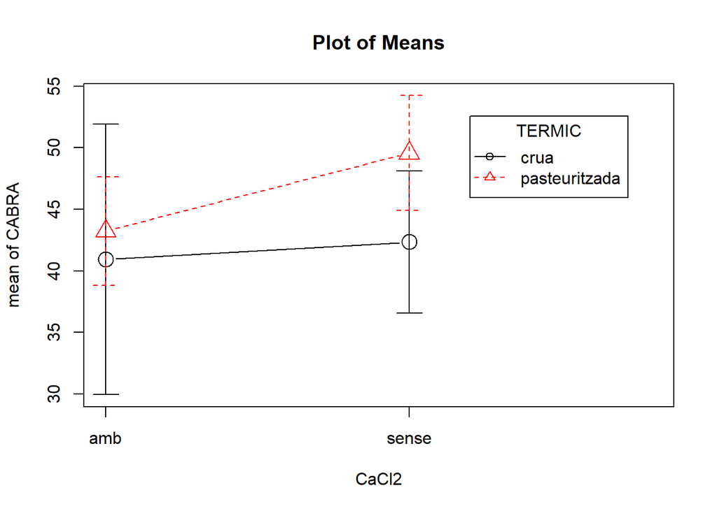

```r
#with(dd, plotMeans(CABRA, TERMIC, CaCl2, error.bars="conf.int", level=0.95, connect=TRUE))
with(dd, plotMeans(CABRA, CaCl2, TERMIC, error.bars="conf.int", level=0.95, connect=TRUE))
```

1. Plantegeu el model factorial:

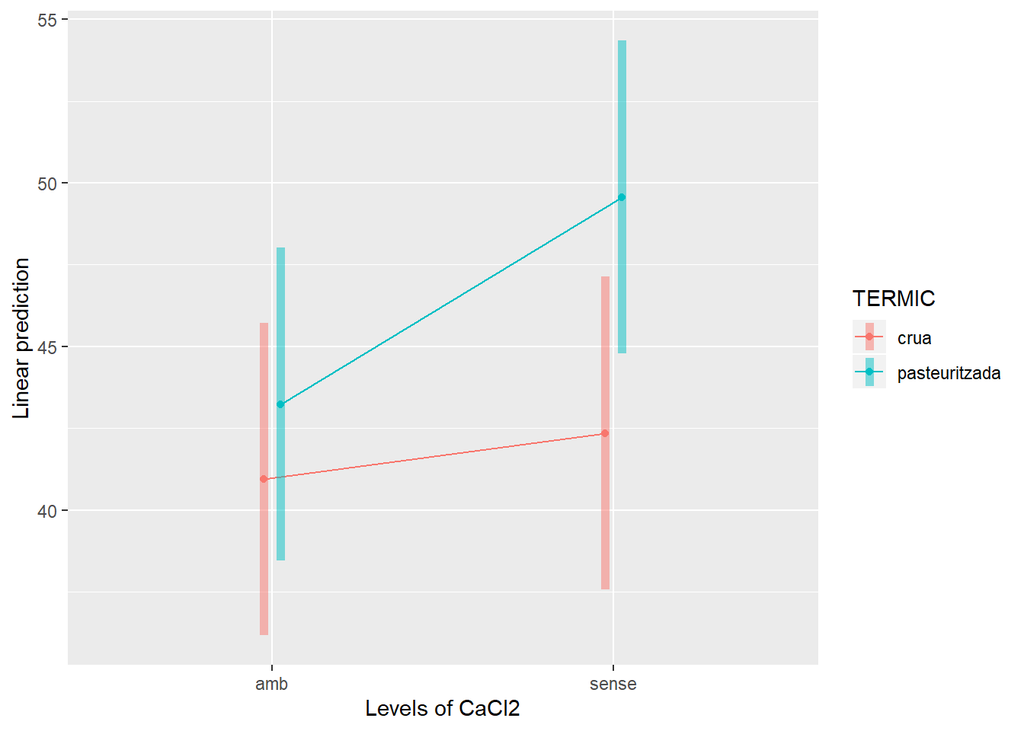

```r
mc<-lm(CABRA~TERMIC*CaCl2,dd)
mc0<-lm(CABRA~1,dd)
emmip(mc,TERMIC~CaCl2,CIs=T)
```

```r
#emmip(mc,CaCl2~TERMIC,CIs=T)
```

Tenen algun efecte els tractaments (combinacions dels nivells dels dos factors) utilitzats? En cas afirmatiu responeu justificadament les preguntes següents:

```r
# Omnibus
anova(mc0,mc)
```

```
## Analysis of Variance Table
##
## Model 1: CABRA ~ 1
## Model 2: CABRA ~ TERMIC * CaCl2
##   Res.Df    RSS Df Sum of Sq      F  Pr(>F)
## 1     15 405.80
## 2     12 231.19  3    174.62 3.0212 0.07157 .
## ---
## Signif. codes:  0 '***' 0.001 '**' 0.01 '*' 0.05 '.' 0.1 ' ' 1
```

```r
#Anova tipus II
Anova(mc)
```

```
## Anova Table (Type II tests)
##
## Response: CABRA
##               Sum Sq Df F value  Pr(>F)
## TERMIC        90.321  1  4.6882 0.05123 .
## CaCl2         59.927  1  3.1105 0.10321
## TERMIC:CaCl2  24.367  1  1.2648 0.28275
## Residuals    231.190 12
## ---
## Signif. codes:  0 '***' 0.001 '**' 0.01 '*' 0.05 '.' 0.1 ' ' 1
```

*El test omnibus no detecte efectes.*

*Amb l’anova (tipus II) els tres efectes són no significatius, el principal TERMIC és no significatiu per molt poc*

**Podem provar de simplificar el model treient la interacció i veure si hi ha algun efecte**

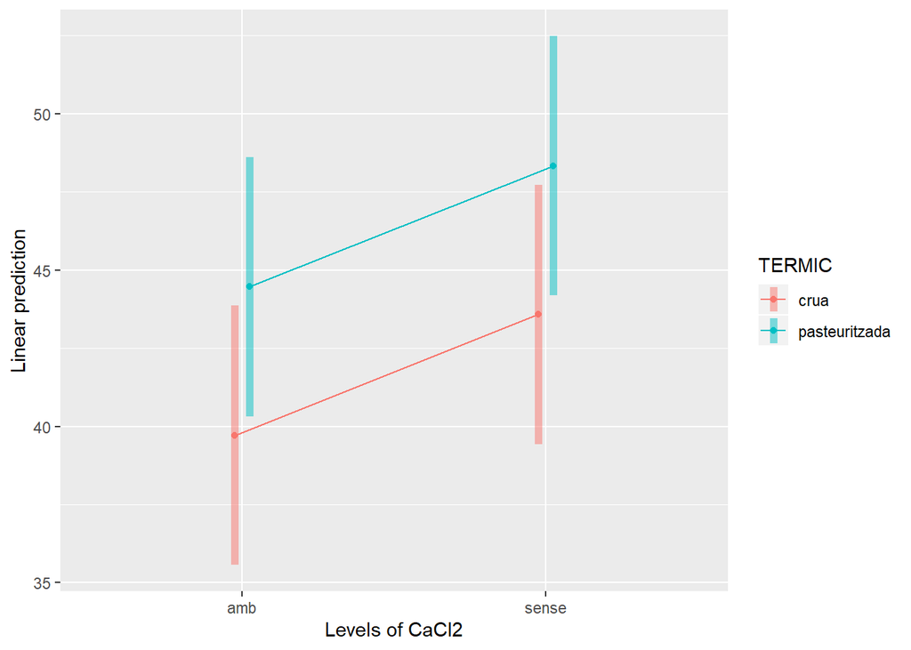

```r
mca<-lm(CABRA~TERMIC+CaCl2,dd)
emmip(mca,TERMIC~CaCl2,CIs=T)
```

```r
#emmip(mca,CaCl2~TERMIC,CIs=T)

# Omnibus
anova(mc0,mca)
```

```
## Analysis of Variance Table
##
## Model 1: CABRA ~ 1
## Model 2: CABRA ~ TERMIC + CaCl2
##   Res.Df    RSS Df Sum of Sq      F Pr(>F)
## 1     15 405.80
## 2     13 255.56  2    150.25 3.8215 0.0495 *
## ---
## Signif. codes:  0 '***' 0.001 '**' 0.01 '*' 0.05 '.' 0.1 ' ' 1
```

```r
#Anova tipus II
Anova(mca)
```

```
## Anova Table (Type II tests)
##
## Response: CABRA
##            Sum Sq Df F value  Pr(>F)
## TERMIC     90.321  1  4.5946 0.05156 .
## CaCl2      59.927  1  3.0485 0.10439
## Residuals 255.556 13
## ---
## Signif. codes:  0 '***' 0.001 '**' 0.01 '*' 0.05 '.' 0.1 ' ' 1
```

*El test omnibus diu que hi ha (per molt poc) algun efecte però l’anova tots surten no significatius, el TERMIC per molt poc. És una situació possible però molt estranya*

**Provem ara amb les comparacions múltiples** *Com que no hi ha interacció ho podem fer per cada factor per separat**

```r
(emmT<-emmeans(mca,~TERMIC))
```

```
##  TERMIC        emmean   SE df lower.CL upper.CL
##  crua            41.6 1.57 13     38.3     45.0
##  pasteuritzada   46.4 1.57 13     43.0     49.8
##
## Results are averaged over the levels of: CaCl2
## Confidence level used: 0.95
```

```r
(emmC<-emmeans(mca,~CaCl2))
```

```
##  CaCl2 emmean   SE df lower.CL upper.CL
##  amb     42.1 1.57 13     38.7     45.5
##  sense   46.0 1.57 13     42.6     49.3
##
## Results are averaged over the levels of: TERMIC
## Confidence level used: 0.95
```

```r
# Comparacions dels tractaments
pairs(emmT)
```

```
##  contrast             estimate   SE df t.ratio p.value
##  crua - pasteuritzada    -4.75 2.22 13 -2.143  0.0516
##
## Results are averaged over the levels of: CaCl2
```

```r
pairs(emmC)
```

```
##  contrast    estimate   SE df t.ratio p.value
##  amb - sense    -3.87 2.22 13 -1.746  0.1044
##
## Results are averaged over the levels of: TERMIC
```

*Tampoc es veuen efectes significatius*

==========================================================================================================

### **Let de OVELLA**

#### **Feu-lo vosaltres**

==========================================================================================================